# Exam_3

Ernie Vilela

11/30/2020

### **TASK I**

Load and clean FacultySalaries_1995.csv file. *Re-create the graph shown in “fig1.png”*

Export it to your Exam_3 folder as LASTNAME_Fig_1.jpg (note, that’s a jpg, not a png)

Please pay attention to what variables are on this graph. This task is really all about whether you can make a tidy dataset out of something a bit wonky.

Refer back to the video where we cleaned “Bird_Measurements.csv”

#### **Resources Used:**

The following libraries were used for completing this assignment.

```r
library(tidyverse)
library(modelr)
library(GGally)
library(lindia)
library(skimr)
library(patchwork)
library(caret)
library(janitor)
library(broom)
```

#### **Loading the data:**

The following loads the data from the FacultySalaries_1995.csv file and puts it into a dataframe called df.

```r
  #this loads the faculty salaries data
df <- read.csv("./FacultySalaries_1995.csv")
```

The following displays the column titles of the faculty salaries dataframe

```r
names(df)
```

```
##  [1] "FedID"               "UnivName"            "State"
##  [4] "Tier"                "AvgFullProfSalary"   "AvgAssocProfSalary"
##  [7] "AvgAssistProfSalary" "AvgProfSalaryAll"    "AvgFullProfComp"
## [10] "AvgAssocProfComp"    "AvgAssistProfComp"   "AvgProfCompAll"
## [13] "NumFullProfs"        "NumAssocProfs"       "NumAssistProfs"
## [16] "NumInstructors"      "NumFacultyAll"
```

Before cleaning up the data, the names will be renamed of the columns, so that we can exactly #recreate the Fig1.png

```r
renamed_df <- df %>% rename(
                      Full = AvgFullProfSalary,
                      Assoc = AvgAssocProfSalary,
                      Assist = AvgAssistProfSalary)
names(renamed_df)
```

```
##  [1] "FedID"             "UnivName"          "State"
##  [4] "Tier"              "Full"              "Assoc"
##  [7] "Assist"            "AvgProfSalaryAll"  "AvgFullProfComp"
## [10] "AvgAssocProfComp"  "AvgAssistProfComp" "AvgProfCompAll"
## [13] "NumFullProfs"      "NumAssocProfs"     "NumAssistProfs"
## [16] "NumInstructors"    "NumFacultyAll"
```

#### **Cleaning up the data:**

We create a Rank column, and a Salary column, allowing us to separate the Salaries by ranking.

-We must create a new dataframe(ranked_df), which contains the updated information.

-Lastly, we filter for only the ranks containing I, IIA, IIB tiers.

```r
ranked_df<- pivot_longer(renamed_df,
                      -c(1:4,8:17),
                      names_to ="Rank",
                      values_to = "Salary",
                      names_prefix ="Rank")

filtered_ranked_df <- filter(ranked_df, Tier == "I" | Tier == "IIA"| Tier == "IIB")
```

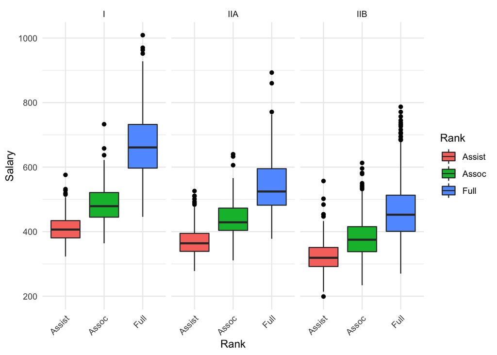

```r
salary_graph <- ggplot(filtered_ranked_df, aes(x=Rank, y=Salary, fill=Rank))+ #This plots the landdata_df dataframe
  facet_wrap(~Tier)+
  geom_boxplot(outlier.color="black")+
  labs(x="Rank", y="Salary")+
  theme_minimal()+
  theme(axis.text.x=element_text(angle = 45, hjust = 1))
salary_graph
```

```r
ggsave("./VILELA_Fig_1.jpg", salary_graph) #saving the image
```

### **TASK II**

Export an ANOVA table to a file called “Salary_ANOVA_Summary.txt”

- The ANOVA model should test the influence of “State”, “Tier”, and “Rank” on “Salary” but should NOT include any interactions between those predictors.

-Then outputting a summary of the Anova table

```r
a_table <- aov(data = ranked_df, Salary ~ State + Tier + Rank)
a_table_summary <- summary(a_table) #this outputs a summary.
a_table_summary
```

```
##               Df   Sum Sq Mean Sq F value Pr(>F)
## State         51  5682396  111420   30.66 <2e-16 ***
## Tier           2  7072361 3536180  972.96 <2e-16 ***
## Rank           2 16529771 8264885 2274.04 <2e-16 ***
## Residuals   3299 11990072    3634
## ---
## Signif. codes:  0 '***' 0.001 '**' 0.01 '*' 0.05 '.' 0.1 ' ' 1
## 128 observations deleted due to missingness
```

-Exporing the summarized anova table

```r
capture.output(a_table_summary, file = "./Salary_ANOVA_Summary.txt")
```

### **TASK III**

*The rest of the test uses another data set. The “Juniper_Oils.csv” data. Get it loaded and take a look.*

It’s not exactly tidy either. Get used to that. It’s real data collected as part of a collaboration between Young Living Inc. and UVU Microbiology. A number of dead cedar trees were collected and the chemical composition of their essential oil content was measured. The hypothesis was that certain chemicals would degrade over time since they died in fires. So there are a bunch of columns for chemical compounds, and a column for “YearsSinceBurn.”

The values under each chemical are Mass-Spec concentrations.Those are the ones the columns we care about for the purposes of this exam.

Guess what, I’m giving you a nicely formatted list of the chemical compounds: c(“alpha-pinene”,“para-cymene”,“alpha-terpineol”,“cedr-9-ene”,“alpha-cedrene”,“beta-cedrene”,“cis-thujopsene”,“alpha-himachalene”,“beta-chamigrene”,“cuparene”,“compound 1”,“alpha-chamigrene”,“widdrol”,“cedrol”,“beta-acorenol”,“alpha-acorenol”,“gamma-eudesmol”,“beta-eudesmol”,“alpha-eudesmol”,“cedr-8-en-13-ol”,“cedr-8-en-15-ol”,“compound 2”,“thujopsenal”)

#### **Loading the data:**

The following loads the data from the Juniper_Oils.csv file and puts it into a dataframe called df1.

-Then outputting a list of the column names

```r
df1 <- read.csv("./Juniper_Oils.csv")
names(df1) #taking a look at the column of df1
```

```
##  [1] "SampleID"               "Project"                "Amplicon"
##  [4] "Tree_Species"           "BurnYear"               "Latitude"
##  [7] "Longitude"              "Field_Office"           "BLM_Fire_Name"
## [10] "Tracking_Number"        "alpha.pinene"           "para.cymene"
## [13] "alpha.terpineol"        "cedr.9.ene"             "alpha.cedrene"
## [16] "beta.cedrene"           "cis.thujopsene"         "alpha.himachalene"
## [19] "beta.chamigrene"        "cuparene"               "compound.1"
## [22] "alpha.chamigrene"       "widdrol"                "cedrol"
## [25] "beta.acorenol"          "alpha.acorenol"         "gamma.eudesmol"
## [28] "beta.eudesmol"          "alpha.eudesmol"         "cedr.8.en.13.ol"
## [31] "cedr.8.en.15.ol"        "compound.2"             "thujopsenal"
## [34] "Yield_percent"          "Bolt_Surface_Area_cm2"  "Raw_Exit_Holes_per_cm2"
## [37] "Raw_Exit_Holes"         "Living_Larvae"          "ChemTotal"
## [40] "ChemMean"               "YearsSinceBurn"
```

#### **Cleaning up the data set**

-Using the janitor package to replaces the capitaliztion for low caps, and the spaces and “-” for "_"

-Then outputting a list of the column names

```r
names(df1) <- janitor::make_clean_names(names(df1))
names(df1)
```

```
##  [1] "sample_id"              "project"                "amplicon"
##  [4] "tree_species"           "burn_year"              "latitude"
##  [7] "longitude"              "field_office"           "blm_fire_name"
## [10] "tracking_number"        "alpha_pinene"           "para_cymene"
## [13] "alpha_terpineol"        "cedr_9_ene"             "alpha_cedrene"
## [16] "beta_cedrene"           "cis_thujopsene"         "alpha_himachalene"
## [19] "beta_chamigrene"        "cuparene"               "compound_1"
## [22] "alpha_chamigrene"       "widdrol"                "cedrol"
## [25] "beta_acorenol"          "alpha_acorenol"         "gamma_eudesmol"
## [28] "beta_eudesmol"          "alpha_eudesmol"         "cedr_8_en_13_ol"
## [31] "cedr_8_en_15_ol"        "compound_2"             "thujopsenal"
## [34] "yield_percent"          "bolt_surface_area_cm2"  "raw_exit_holes_per_cm2"
## [37] "raw_exit_holes"         "living_larvae"          "chem_total"
## [40] "chem_mean"              "years_since_burn"
```

-Using the janitor package, we also clean up the list given.

-We also use the janitor package to accomplish this.

```r
list_chemicals <- c("alpha-pinene","para-cymene","alpha-terpineol","cedr-9-ene","alpha-cedrene",
                    "beta-cedrene","cis-thujopsene","alpha-himachalene","beta-chamigrene","cuparene",
                    "compound 1","alpha-chamigrene","widdrol","cedrol","beta-acorenol","alpha-acorenol",
                    "gamma-eudesmol","beta-eudesmol","alpha-eudesmol","cedr-8-en-13-ol","cedr-8-en-15-ol",
                    "compound 2","thujopsenal")
print(list_chemicals)
```

```
##  [1] "alpha-pinene"      "para-cymene"       "alpha-terpineol"
##  [4] "cedr-9-ene"        "alpha-cedrene"     "beta-cedrene"
##  [7] "cis-thujopsene"    "alpha-himachalene" "beta-chamigrene"
## [10] "cuparene"          "compound 1"        "alpha-chamigrene"
## [13] "widdrol"           "cedrol"            "beta-acorenol"
## [16] "alpha-acorenol"    "gamma-eudesmol"    "beta-eudesmol"
## [19] "alpha-eudesmol"    "cedr-8-en-13-ol"   "cedr-8-en-15-ol"
## [22] "compound 2"        "thujopsenal"
```

```r
list_chemicals <- janitor::make_clean_names(print(list_chemicals))
```

```
##  [1] "alpha-pinene"      "para-cymene"       "alpha-terpineol"
##  [4] "cedr-9-ene"        "alpha-cedrene"     "beta-cedrene"
##  [7] "cis-thujopsene"    "alpha-himachalene" "beta-chamigrene"
## [10] "cuparene"          "compound 1"        "alpha-chamigrene"
## [13] "widdrol"           "cedrol"            "beta-acorenol"
## [16] "alpha-acorenol"    "gamma-eudesmol"    "beta-eudesmol"
## [19] "alpha-eudesmol"    "cedr-8-en-13-ol"   "cedr-8-en-15-ol"
## [22] "compound 2"        "thujopsenal"
```

```r
print(list_chemicals)
```

```
##  [1] "alpha_pinene"      "para_cymene"       "alpha_terpineol"
##  [4] "cedr_9_ene"        "alpha_cedrene"     "beta_cedrene"
##  [7] "cis_thujopsene"    "alpha_himachalene" "beta_chamigrene"
## [10] "cuparene"          "compound_1"        "alpha_chamigrene"
## [13] "widdrol"           "cedrol"            "beta_acorenol"
## [16] "alpha_acorenol"    "gamma_eudesmol"    "beta_eudesmol"
## [19] "alpha_eudesmol"    "cedr_8_en_13_ol"   "cedr_8_en_15_ol"
## [22] "compound_2"        "thujopsenal"
```

#### **Selecting the data wanted (chemical compounds)**

-Now we can select the data we want: We are going to get the list of chemicals that we care about out of df1.

```r
df1_select_chemicals <- select(df1, "years_since_burn", all_of(list_chemicals))
head(df1_select_chemicals) #looking at the data frame structure
```

```
##   years_since_burn alpha_pinene para_cymene alpha_terpineol cedr_9_ene
## 1                2          0.6         0.4             2.3        0.2
## 2                3          1.4         0.3             0.5        1.0
## 3                4          0.2         1.1             0.8        1.1
## 4                6          0.3         0.1             0.7        0.7
## 5                7          0.1         0.1             0.2        1.0
## 6                8          0.0         0.1             0.1        0.3
##   alpha_cedrene beta_cedrene cis_thujopsene alpha_himachalene beta_chamigrene
## 1           1.9          1.2          25.90               0.2             0.4
## 2           9.5          3.3          22.80               0.4             1.1
## 3          13.2          3.2          12.50               0.4             1.8
## 4           6.7          2.3          19.98               0.3             0.8
## 5           8.1          2.9          14.00               0.4             0.9
## 6           9.4          1.8           9.30               0.2             1.0
##   cuparene compound_1 alpha_chamigrene widdrol cedrol beta_acorenol
```

[output cut: 20 more lines]

-We output the column names of the selected chemicals

```r
names(df1_select_chemicals) #looking at the column names
```

```
##  [1] "years_since_burn"  "alpha_pinene"      "para_cymene"
##  [4] "alpha_terpineol"   "cedr_9_ene"        "alpha_cedrene"
##  [7] "beta_cedrene"      "cis_thujopsene"    "alpha_himachalene"
## [10] "beta_chamigrene"   "cuparene"          "compound_1"
## [13] "alpha_chamigrene"  "widdrol"           "cedrol"
## [16] "beta_acorenol"     "alpha_acorenol"    "gamma_eudesmol"
## [19] "beta_eudesmol"     "alpha_eudesmol"    "cedr_8_en_13_ol"
## [22] "cedr_8_en_15_ol"   "compound_2"        "thujopsenal"
```

-Now we turn it into a long format

```r
df1_select_chemicals_longer <- pivot_longer(df1_select_chemicals,
                                            cols = list_chemicals,
                                            names_to= "compound",
                                            values_to= "concentration")
head(df1_select_chemicals_longer) #looking at the data frame structure
```

```
## # A tibble: 6 x 3
##   years_since_burn compound        concentration
##              <int> <chr>                   <dbl>
## 1                2 alpha_pinene              0.6
## 2                2 para_cymene               0.4
## 3                2 alpha_terpineol           2.3
## 4                2 cedr_9_ene                0.2
## 5                2 alpha_cedrene             1.9
## 6                2 beta_cedrene              1.2
```

-We output the column names of the selected chemicals in long format

```r
names(df1_select_chemicals_longer) #looking at the column names
```

```
## [1] "years_since_burn" "compound"         "concentration"
```

### **TASK IV**

Make me a graph of the following: x = YearsSinceBurn y = Concentration facet = ChemicalID (use free y-axis scales) *See Fig2.png for an idea of what I’m looking for.*

-Making the plot, and saving it into a variable called chemical_graph

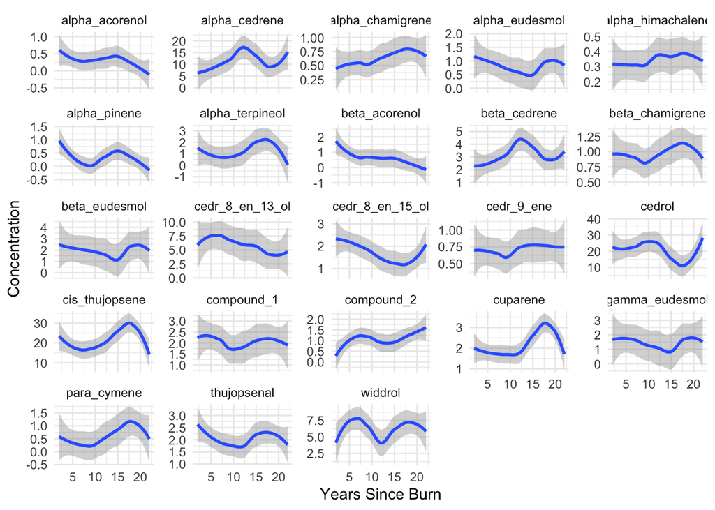

```r
chemical_graph <- ggplot(df1_select_chemicals_longer, aes(x=years_since_burn, y=concentration))+
  facet_wrap(~compound, scales= "free_y")+
  theme_minimal()+
  geom_smooth()+
  labs(x="Years Since Burn", y = "Concentration")
chemical_graph
```

-Saving the graph.

```r
ggsave("./VILELA_Fig_2.jpg", chemical_graph)
```

### **TASK V**

Use a generalized linear model to find which chemicals show concentrations that are significantly (significant, as in P < 0.05) affected by “Years Since Burn”. Use the tidy() function from the broom R package (Thank Dalton for asking about this) in order to produce a data frame showing JUST the significant chemicals and their model output (coefficient estimates, p-values, etc)

-We first change the y-axis values to plain numeric

```r
options(scipen = 999)#this changes the y-axis values to plain numeric
```

-We make a generilized linear model

```r
mod1 <- glm(data=df1_select_chemicals_longer, concentration ~ years_since_burn * compound)
mod1
```

```
##
## Call:  glm(formula = concentration ~ years_since_burn * compound, data = df1_select_chemicals_longer)
##
## Coefficients:
##                                (Intercept)
##                                   0.546972
##                           years_since_burn
##                                  -0.022323
##                      compoundalpha_cedrene
##                                   7.881098
##                   compoundalpha_chamigrene
##                                  -0.097195
##                     compoundalpha_eudesmol
##                                   0.361341
##                  compoundalpha_himachalene
##                                  -0.240541
##                       compoundalpha_pinene
##                                   0.049025
##                    compoundalpha_terpineol
##                                   0.445621
##                      compoundbeta_acorenol
##                                   0.829371
##                       compoundbeta_cedrene
##                                   2.118457
##                    compoundbeta_chamigrene
##                                   0.366045
##                      compoundbeta_eudesmol
##                                   1.428395
##                    compoundcedr_8_en_13_ol
##                                   7.619740
##                    compoundcedr_8_en_15_ol
##                                   1.710281
##                         compoundcedr_9_ene
##                                   0.125488
##                             compoundcedrol
##                                  22.548238
##                     compoundcis_thujopsene
##                                  17.277800
##                         compoundcompound_1
##                                   1.726651
```

[output cut: 45 more lines]

```
##                                   0.057963
##          years_since_burn:compoundcuparene
##                                   0.077284
##    years_since_burn:compoundgamma_eudesmol
##                                   0.023221
##       years_since_burn:compoundpara_cymene
##                                   0.056406
##       years_since_burn:compoundthujopsenal
##                                   0.014138
##           years_since_burn:compoundwiddrol
##                                   0.026360
##
## Degrees of Freedom: 781 Total (i.e. Null);  736 Residual
## Null Deviance:       36650
## Residual Deviance: 10080     AIC: 4312
```

-We tidy up the generalized linear model

```r
tidymod <- tidy(mod1)
tidymod #glimpsing at our tidy data
```

```
## # A tibble: 46 x 5
##    term                      estimate std.error statistic   p.value
##    <chr>                        <dbl>     <dbl>     <dbl>     <dbl>
##  1 (Intercept)                 0.547     1.37      0.401  0.689
##  2 years_since_burn           -0.0223    0.0998   -0.224  0.823
##  3 compoundalpha_cedrene       7.88      1.93      4.08   0.0000497
##  4 compoundalpha_chamigrene   -0.0972    1.93     -0.0503 0.960
##  5 compoundalpha_eudesmol      0.361     1.93      0.187  0.852
##  6 compoundalpha_himachalene  -0.241     1.93     -0.125  0.901
##  7 compoundalpha_pinene        0.0490    1.93      0.0254 0.980
##  8 compoundalpha_terpineol     0.446     1.93      0.231  0.818
##  9 compoundbeta_acorenol       0.829     1.93      0.429  0.668
## 10 compoundbeta_cedrene        2.12      1.93      1.10   0.273
## # … with 36 more rows
```

-We filter the tidy generalized linear model, and we select only the concentrations with significant p-values

```r
significant_tidymod <- filter(tidymod, p.value < 0.05)
significant_tidymod #glimpsing at our filtered data for significant values
```

```
## # A tibble: 6 x 5
##   term                                    estimate std.error statistic  p.value
##   <chr>                                      <dbl>     <dbl>     <dbl>    <dbl>
## 1 compoundalpha_cedrene                      7.88      1.93       4.08 4.97e- 5
## 2 compoundcedr_8_en_13_ol                    7.62      1.93       3.95 8.72e- 5
## 3 compoundcedrol                            22.5       1.93      11.7  5.12e-29
## 4 compoundcis_thujopsene                    17.3       1.93       8.95 2.93e-18
## 5 compoundwiddrol                            5.82      1.93       3.01 2.69e- 3
## 6 years_since_burn:compoundcis_thujopsene    0.332     0.141      2.35 1.90e- 2
```

-For aesthetic purposes, and in order to match the example given, we will remove the compound prefix that is found at the beginning of each chemical

```r
#removing the prefix 'compound' in our final data output
significant_tidymod$term <- gsub("compound", "", significant_tidymod$term)
significant_tidymod
```

```
## # A tibble: 6 x 5
##   term                            estimate std.error statistic  p.value
##   <chr>                              <dbl>     <dbl>     <dbl>    <dbl>
## 1 alpha_cedrene                      7.88      1.93       4.08 4.97e- 5
## 2 cedr_8_en_13_ol                    7.62      1.93       3.95 8.72e- 5
## 3 cedrol                            22.5       1.93      11.7  5.12e-29
## 4 cis_thujopsene                    17.3       1.93       8.95 2.93e-18
## 5 widdrol                            5.82      1.93       3.01 2.69e- 3
## 6 years_since_burn:cis_thujopsene    0.332     0.141      2.35 1.90e- 2
```

### **TASK VI**

Commit and push all your code and files to GitHub.

[Click to here visit Github Repository](https://github.com/ErnieVc/Data_Course_VILELA)